# Final Project Part 2

Madhumathi_Sekar, Thy Kieu, & Madhuri Patibandla

2025-04-01

# Dataset overview

```r
df_2009_2010 <- read_excel("D:/online_retail_II.xlsx", sheet = 1)
df_2010_2011 <- read_excel("D:/online_retail_II.xlsx", sheet = 2)

# combine both the datasets
df <- bind_rows(df_2009_2010,df_2010_2011)

df
```

```
## # A tibble: 1,067,371 × 8
##    Invoice StockCode Description              Quantity InvoiceDate         Price
##    <chr>   <chr>     <chr>                       <dbl> <dttm>              <dbl>
##  1 489434  85048     "15CM CHRISTMAS GLASS B…       12 2009-12-01 07:45:00  6.95
##  2 489434  79323P    "PINK CHERRY LIGHTS"           12 2009-12-01 07:45:00  6.75
##  3 489434  79323W    "WHITE CHERRY LIGHTS"          12 2009-12-01 07:45:00  6.75
##  4 489434  22041     "RECORD FRAME 7\" SINGL…       48 2009-12-01 07:45:00  2.1
##  5 489434  21232     "STRAWBERRY CERAMIC TRI…       24 2009-12-01 07:45:00  1.25
##  6 489434  22064     "PINK DOUGHNUT TRINKET …       24 2009-12-01 07:45:00  1.65
##  7 489434  21871     "SAVE THE PLANET MUG"          24 2009-12-01 07:45:00  1.25
##  8 489434  21523     "FANCY FONT HOME SWEET …       10 2009-12-01 07:45:00  5.95
##  9 489435  22350     "CAT BOWL"                     12 2009-12-01 07:46:00  2.55
## 10 489435  22349     "DOG BOWL , CHASING BAL…       12 2009-12-01 07:46:00  3.75
## # ℹ 1,067,361 more rows
## # ℹ 2 more variables: `Customer ID` <dbl>, Country <chr>
```

# Exploratory Data Analysis

> Check first few rows

```r
head(df)
```

```
## # A tibble: 6 × 8
##   Invoice StockCode Description Quantity InvoiceDate         Price `Customer ID`
##   <chr>   <chr>     <chr>          <dbl> <dttm>              <dbl>         <dbl>
## 1 489434  85048     "15CM CHRI…       12 2009-12-01 07:45:00  6.95         13085
## 2 489434  79323P    "PINK CHER…       12 2009-12-01 07:45:00  6.75         13085
## 3 489434  79323W    "WHITE CHE…       12 2009-12-01 07:45:00  6.75         13085
## 4 489434  22041     "RECORD FR…       48 2009-12-01 07:45:00  2.1          13085
## 5 489434  21232     "STRAWBERR…       24 2009-12-01 07:45:00  1.25         13085
## 6 489434  22064     "PINK DOUG…       24 2009-12-01 07:45:00  1.65         13085
## # ℹ 1 more variable: Country <chr>
```

> Check summary statistics

```r
summary(df)
```

```
##    Invoice           StockCode         Description           Quantity
##  Length:1067371     Length:1067371     Length:1067371     Min.   :-80995.00
##  Class :character   Class :character   Class :character   1st Qu.:     1.00
##  Mode  :character   Mode  :character   Mode  :character   Median :     3.00
##                                                           Mean   :     9.94
##                                                           3rd Qu.:    10.00
##                                                           Max.   : 80995.00
##
##   InvoiceDate                         Price            Customer ID
##  Min.   :2009-12-01 07:45:00.00   Min.   :-53594.36   Min.   :12346
##  1st Qu.:2010-07-09 09:46:00.00   1st Qu.:     1.25   1st Qu.:13975
##  Median :2010-12-07 15:28:00.00   Median :     2.10   Median :15255
##  Mean   :2011-01-02 21:13:55.39   Mean   :     4.65   Mean   :15325
##  3rd Qu.:2011-07-22 10:23:00.00   3rd Qu.:     4.15   3rd Qu.:16797
##  Max.   :2011-12-09 12:50:00.00   Max.   : 38970.00   Max.   :18287
##                                                       NA's   :243007
##    Country
##  Length:1067371
##  Class :character
##  Mode  :character
##
##
##
##
```

> Check structure of data

```r
str(df)
```

```
## tibble [1,067,371 × 8] (S3: tbl_df/tbl/data.frame)
##  $ Invoice    : chr [1:1067371] "489434" "489434" "489434" "489434" ...
##  $ StockCode  : chr [1:1067371] "85048" "79323P" "79323W" "22041" ...
##  $ Description: chr [1:1067371] "15CM CHRISTMAS GLASS BALL 20 LIGHTS" "PINK CHERRY LIGHTS" "WHITE CHERRY LIGHTS" "RECORD FRAME 7\" SINGLE SIZE" ...
##  $ Quantity   : num [1:1067371] 12 12 12 48 24 24 24 10 12 12 ...
##  $ InvoiceDate: POSIXct[1:1067371], format: "2009-12-01 07:45:00" "2009-12-01 07:45:00" ...
##  $ Price      : num [1:1067371] 6.95 6.75 6.75 2.1 1.25 1.65 1.25 5.95 2.55 3.75 ...
##  $ Customer ID: num [1:1067371] 13085 13085 13085 13085 13085 ...
##  $ Country    : chr [1:1067371] "United Kingdom" "United Kingdom" "United Kingdom" "United Kingdom" ...
```

> Check Missing Values Count

```r
colSums(is.na(df))
```

```
##     Invoice   StockCode Description    Quantity InvoiceDate       Price
##           0           0        4382           0           0           0
## Customer ID     Country
##      243007           0
```

> Rename the column CustomerID

```r
colnames(df) <- gsub(" ","",colnames(df))

colnames(df)
```

```
## [1] "Invoice"     "StockCode"   "Description" "Quantity"    "InvoiceDate"
## [6] "Price"       "CustomerID"  "Country"
```

Since we have more missing CustomerID ,replacing them with “Unknown”

```r
df <- df %>%
  mutate(CustomerID = ifelse(is.na(CustomerID), "Unknown", as.character(CustomerID)))
```

> Remove Duplicates

```r
df <- df |> distinct()
```

> Transformations

```r
df_Transformation <- df |>
filter(Country=="United Kingdom") |>
mutate(Month = month.abb[month(InvoiceDate)])|>
mutate(Total_Price = sum(Quantity * Price))
df_Transformation
```

```
## # A tibble: 948,321 × 10
##    Invoice StockCode Description   Quantity InvoiceDate         Price CustomerID
##    <chr>   <chr>     <chr>            <dbl> <dttm>              <dbl> <chr>
##  1 489434  85048     "15CM CHRIST…       12 2009-12-01 07:45:00  6.95 13085
##  2 489434  79323P    "PINK CHERRY…       12 2009-12-01 07:45:00  6.75 13085
##  3 489434  79323W    "WHITE CHERR…       12 2009-12-01 07:45:00  6.75 13085
##  4 489434  22041     "RECORD FRAM…       48 2009-12-01 07:45:00  2.1  13085
##  5 489434  21232     "STRAWBERRY …       24 2009-12-01 07:45:00  1.25 13085
##  6 489434  22064     "PINK DOUGHN…       24 2009-12-01 07:45:00  1.65 13085
##  7 489434  21871     "SAVE THE PL…       24 2009-12-01 07:45:00  1.25 13085
##  8 489434  21523     "FANCY FONT …       10 2009-12-01 07:45:00  5.95 13085
##  9 489435  22350     "CAT BOWL"          12 2009-12-01 07:46:00  2.55 13085
## 10 489435  22349     "DOG BOWL , …       12 2009-12-01 07:46:00  3.75 13085
## # ℹ 948,311 more rows
## # ℹ 3 more variables: Country <chr>, Month <chr>, Total_Price <dbl>
```

This transformation was done to calculate the total revenue.

> Daily Sales Trend

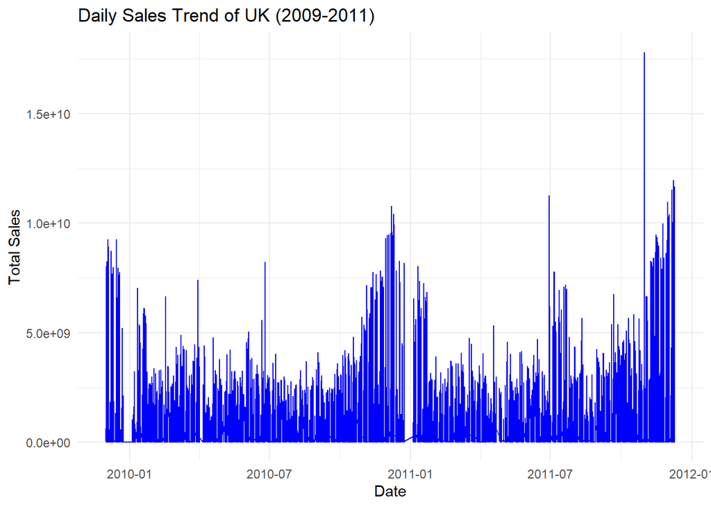

```r
df_daily_sales <- df_Transformation |>
  group_by(InvoiceDate) |>
  summarise(Total_Sales = sum(Total_Price, na.rm = TRUE))

ggplot(df_daily_sales, aes(x = InvoiceDate, y = Total_Sales)) +
  geom_line(color = "blue") +
  labs(title = "Daily Sales Trend of UK (2009-2011)", x = "Date", y = "Total Sales") +
  theme_minimal()
```

Looking at the daily sales trend from 2009 to 2011, there is a general upward trend. There seems to be higher peaks in the later periods. Seasonality-wise, there are recurring peaks and dips at regular intervals. There a spikes around the end of the year possibly due to seasonal effects. Overall, it is not stationary.

> Monthly Sales Trend

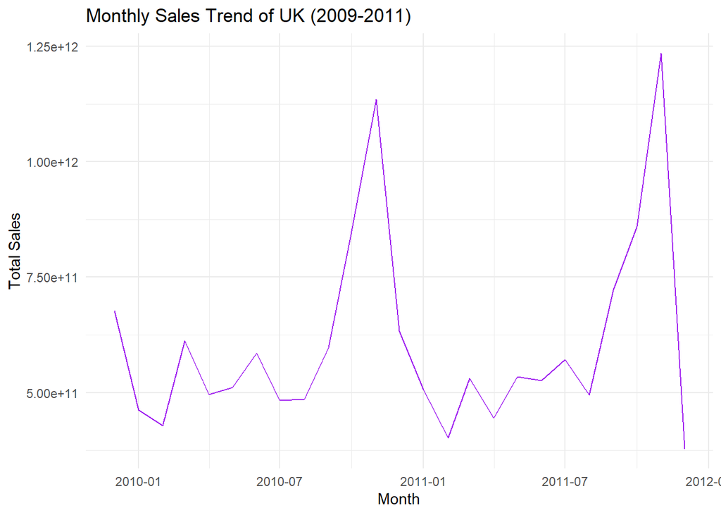

```r
df_monthly_sales <- df_Transformation |>
  mutate(YearMonth = floor_date(InvoiceDate, "month")) |>
  group_by(YearMonth) |>
  summarise(Total_Sales = sum(Total_Price, na.rm = TRUE))

# Plot Monthly Sales Trend
ggplot(df_monthly_sales, aes(x = YearMonth, y = Total_Sales)) +
  geom_line(color = "purple") +
  labs(title = "Monthly Sales Trend of UK (2009-2011)", x = "Month", y = "Total Sales") +
  theme_minimal()
```

Looking at the monthly sale trends, from the beginning to the end of each year, there is an upward trend. Again, it also shows yearly seasonality where it spikes around the end of the year(possibly due to holiday sales). This graph is not stationary.

> Yearly Sales Trend

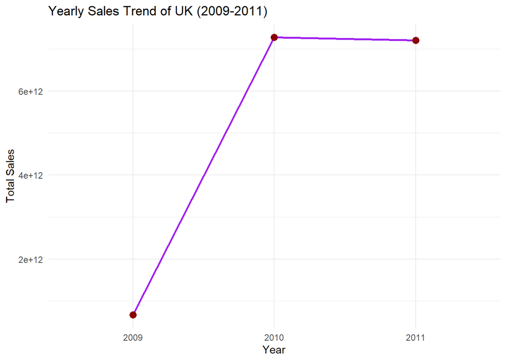

```r
df_yearly_sales <- df_Transformation |>
  mutate(Year = year(InvoiceDate)) |>
  group_by(Year) |>
  summarise(Total_Sales = sum(Total_Price, na.rm = TRUE))


ggplot(df_yearly_sales, aes(x = factor(Year), y = Total_Sales, group = 1)) +
  geom_line(color = "purple", size = 1) +
  geom_point(size = 3, color = "darkred") +
  labs(title = "Yearly Sales Trend of UK (2009-2011)", x = "Year", y = "Total Sales") +
  theme_minimal()
```

Looking at the yearly sales trend, there is an increase from 2009 to 2010, and then a small decrease from 2010 to 2011. Seasonality and stationary can’t be assessed.

```r
df_monthly_sales_MY <- df_Transformation %>%
  mutate(YearMonth = yearmonth(InvoiceDate)) %>%  # Convert date to Year-Month
  group_by(YearMonth) %>%
  summarise(Total_Sales = sum(Total_Price, na.rm = TRUE), .groups = "drop")

# Converting to tsibble
df_UK_ts <- as_tsibble(df_monthly_sales_MY, index = YearMonth)
```

# Time Series Visualization

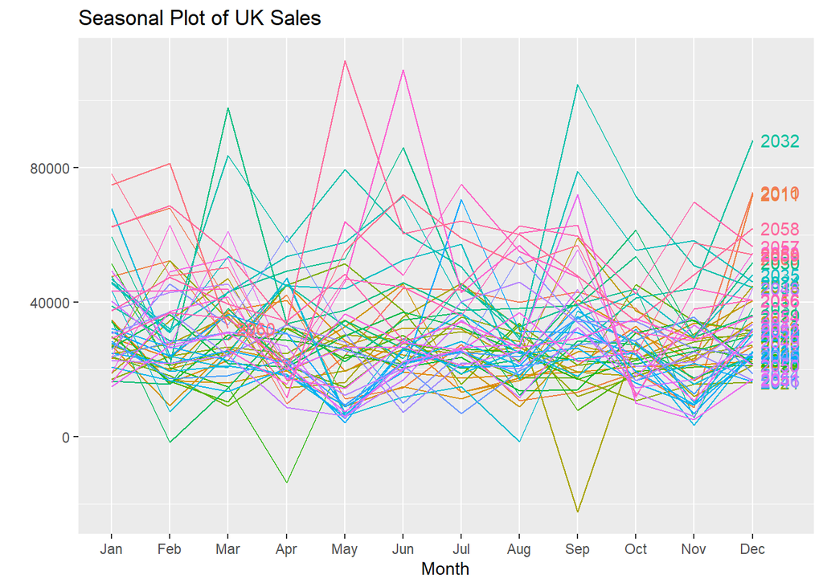

```r
#transformation with invoicedate to a date format
df$InvoiceDate <- as_datetime(df$InvoiceDate)
df_data <- df %>%
  mutate(Date = as.Date(InvoiceDate)) %>%
  group_by(Date) %>%
  summarise(TotalPrice = sum(Quantity * Price, na.rm = TRUE))

#time series
ts <- ts(df_data$TotalPrice, start=c(2009,12), frequency=12)

#seasonal plot
ggseasonplot(ts, main="Seasonal Plot of UK Sales", year.labels=TRUE)
```

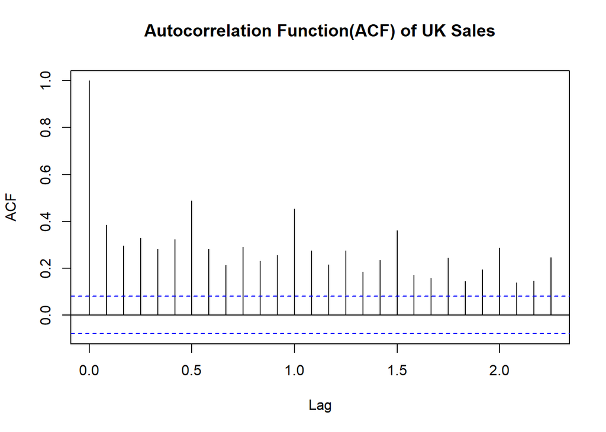

```r
#ACF plot
acf(ts, main = "Autocorrelation Function(ACF) of UK Sales")
```

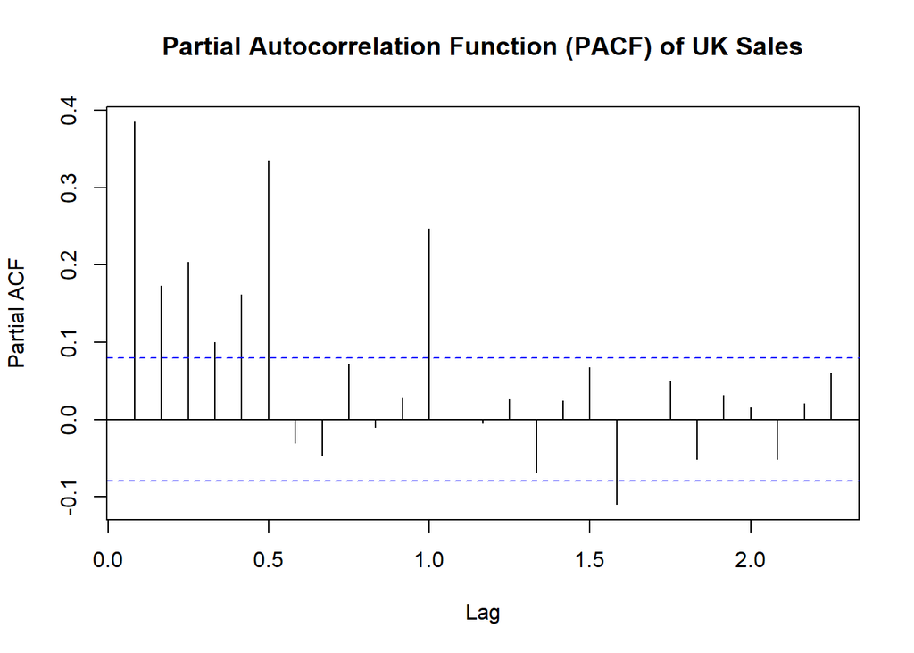

```r
#PACF plot
pacf(ts, main="Partial Autocorrelation Function (PACF) of UK Sales")
```

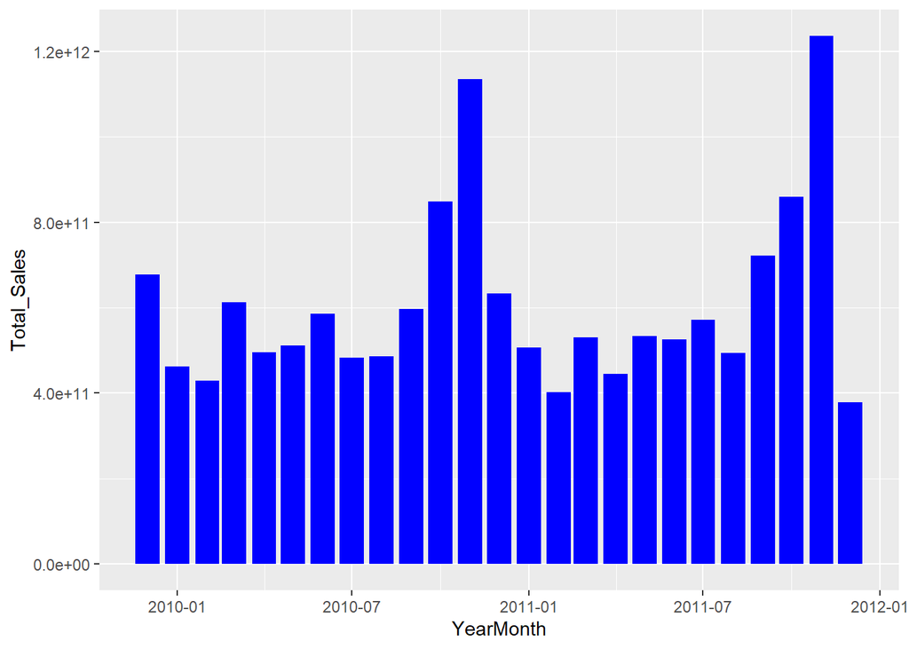

```r
#bar plot
ggplot(df_monthly_sales, aes(x = YearMonth, y = Total_Sales)) +
  geom_bar(stat = "identity", fill = "blue")
```

```r
  labs(title = "Bar Plot of Monthly Sales Trend of UK (2009-2011)", x = "Month", y = "Total Sales")
```

```
## $x
## [1] "Month"
##
## $y
## [1] "Total Sales"
##
## $title
## [1] "Bar Plot of Monthly Sales Trend of UK (2009-2011)"
##
## attr(,"class")
## [1] "labels"
```

# Time Series Decomposition

> Classical Decomposition(Additive)

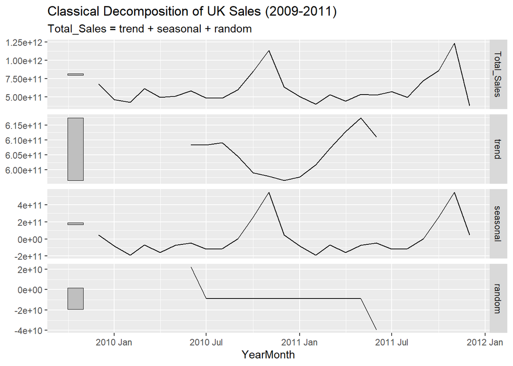

```r
decomp <- df_UK_ts %>%
  model(classical_decomposition(Total_Sales, type = "additive")) %>%
  components()

# Plot decomposition
autoplot(decomp) +
  labs(title = "Classical Decomposition of UK Sales (2009-2011)")
```

The classical decomposition to the total_sales variable was executed using the “additive” type because the seasonal variations were constant over time. The trend line is increasing with a slight decline around the end, so there is a non-stationary trend in sales. The seasonal component shows strong seasonality due to the recurring patterns.

> STL Decomposition

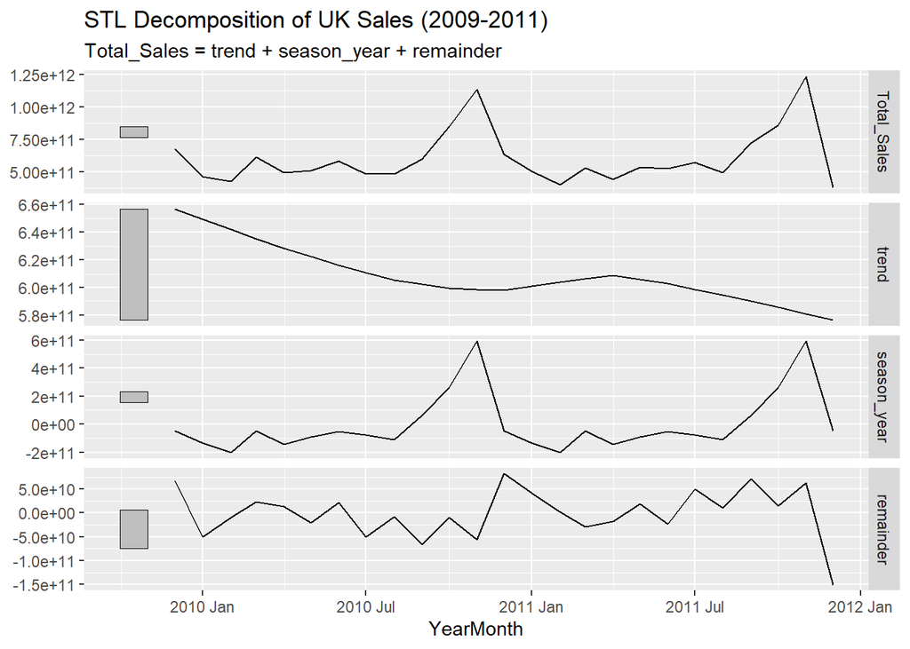

```r
stl_decomp <- df_UK_ts %>%
  model(STL(Total_Sales ~ season(window = "periodic"))) %>%
  components()

# Plot STL Decomposition
autoplot(stl_decomp) +
  labs(title = "STL Decomposition of UK Sales (2009-2011)")
```

The STL decomposition was used because it allows for changing seasonal patterns. It shows an overall downward trend. There seems to be signs of seasonality due to the recurring patterns. The remainder/residuals show the possible noise and irregularities.

> Predictions

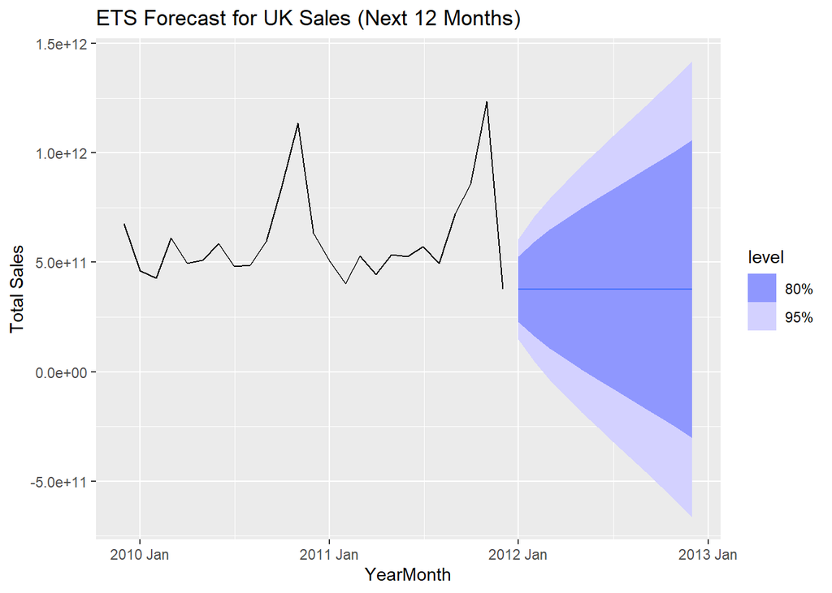

```r
# ETS Model
ets_model <- df_UK_ts %>%
  model(ETS(Total_Sales))

# Forecast for next 12 months
ets_forecast <- forecast(ets_model, h = 12)

# Plot
autoplot(ets_forecast, df_UK_ts) +
  labs(title = "ETS Forecast for UK Sales (Next 12 Months)", y = "Total Sales")
```

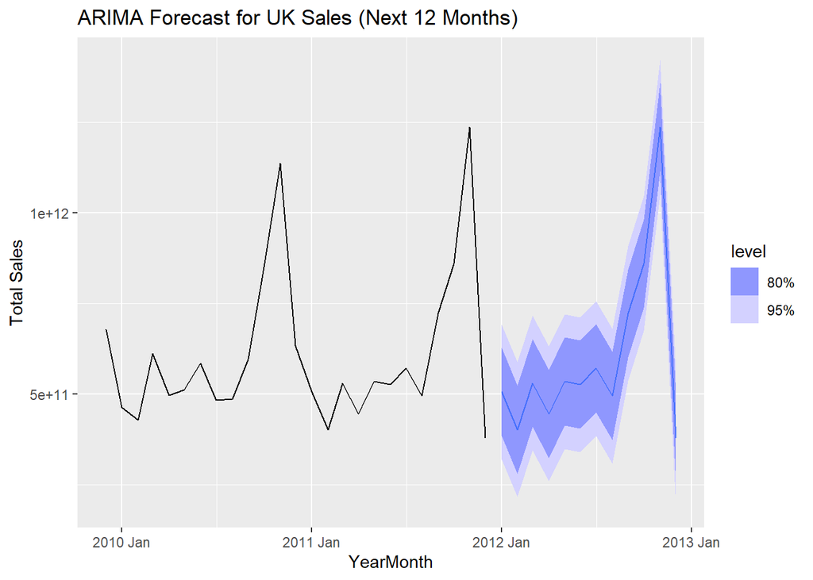

```r
# Fit ARIMA Model
arima_model <- df_UK_ts %>%
  model(ARIMA(Total_Sales))

# Forecast for next 12 months
arima_forecast <- forecast(arima_model, h = 12)

# Plot
autoplot(arima_forecast, df_UK_ts) +
  labs(title = "ARIMA Forecast for UK Sales (Next 12 Months)", y = "Total Sales")
```

```r
# Compare both ETS and ARIMA
model_compare <- df_UK_ts %>%
  model(
    ETS = ETS(Total_Sales),
    ARIMA = ARIMA(Total_Sales)
  )

# Accuracy
glance(model_compare)
```

```
## # A tibble: 2 × 11
##   .model   sigma2 log_lik   AIC  AICc   BIC      MSE     AMSE    MAE ar_roots
##   <chr>     <dbl>   <dbl> <dbl> <dbl> <dbl>    <dbl>    <dbl>  <dbl> <list>
## 1 ETS    9.51e- 2   -687. 1380. 1382. 1384.  6.22e22  7.47e22  0.247 <NULL>
## 2 ARIMA  8.98e+21   -347.  696.  696.  697. NA       NA       NA     <cpl [0]>
## # ℹ 1 more variable: ma_roots <list>
```

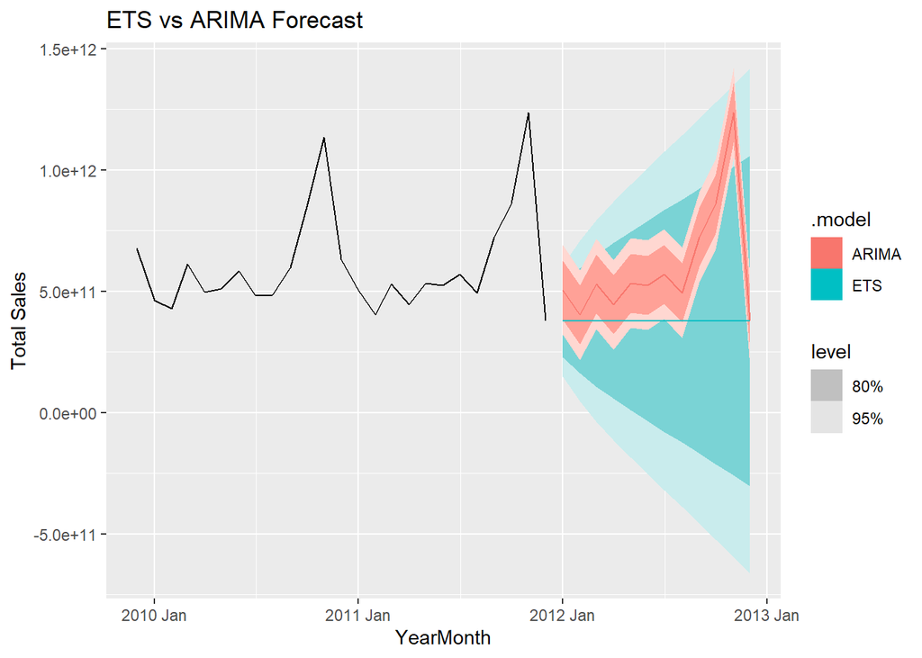

```r
# Forecast with both
combined_forecast <- forecast(model_compare, h = 12)

# Plot comparison
autoplot(combined_forecast, df_UK_ts) +
  labs(title = "ETS vs ARIMA Forecast", y = "Total Sales")
```

```r
# Create training set (excluding last 6 months for testing)
train_data <- df_UK_ts %>% filter_index(. ~ "2011-06")

# Train and test
model_train <- train_data %>%
  model(ETS = ETS(Total_Sales), ARIMA = ARIMA(Total_Sales))

# Forecast
fc <- forecast(model_train, h = 6)

# Actual data
actual <- df_UK_ts %>% filter_index("2011-07" ~ .)

# Accuracy
accuracy(fc, actual)
```

```
## # A tibble: 2 × 10
##   .model .type            ME        RMSE     MAE   MPE  MAPE  MASE RMSSE    ACF1
##   <chr>  <chr>         <dbl>       <dbl>   <dbl> <dbl> <dbl> <dbl> <dbl>   <dbl>
## 1 ARIMA  Test  260427215234.     3.92e11 2.68e11  26.8  28.7   NaN   NaN -0.0400
## 2 ETS    Test  184004031318.     3.36e11 2.44e11  14.3  29.5   NaN   NaN -0.141
```

The Evaluate Forecast Accuracy model with lower values for MAE, RMSE, and MAPE is considered more accurate.

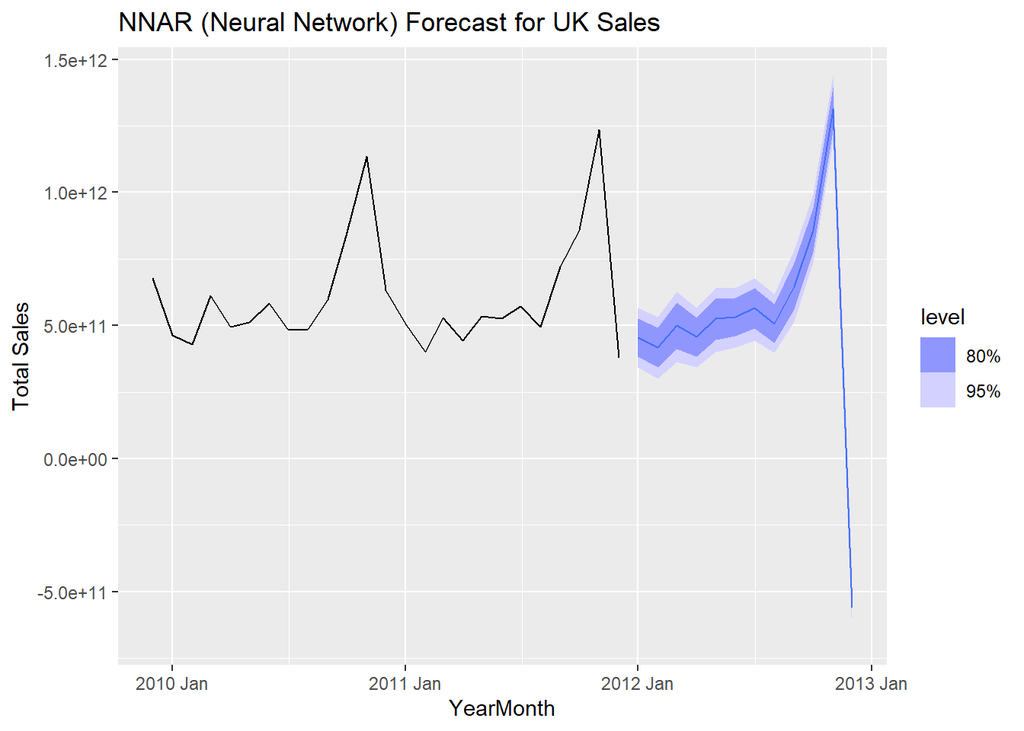

```r
# Neural Network Model
nn_model <- df_UK_ts %>%
  model(NNAR = NNETAR(Total_Sales))

# Forecast next 12 months
nn_forecast <- forecast(nn_model, h = 12)

# Plot NNAR forecast
autoplot(nn_forecast, df_UK_ts) +
  labs(title = "NNAR (Neural Network) Forecast for UK Sales", y = "Total Sales")
```

X-axis: Time — monthly from your historical data (YearMonth).Y-axis: Total_Sales — total sales in the UK per month. Solid Line (Historical Data): This shows the actual sales observed from 2009 to 2011. Forecast Line (Dashed or Extended Line): The NNAR model’s forecasted sales for the next 12 months. Shaded Area (Confidence Intervals): These indicate the range of uncertainty around the forecasts (typically 80% and 95% prediction intervals).

> Team Contribution

Madhumathi Sekar: Time series decomposition, time series visualization, TS models Thy Kieu: Description of graphs and time series models, time series visualization Madhuri Patibandla: Worked on Exponential smoothing, ARIMA and neural network models to predict the forecast on the online sale.